# Data Tidak Stasioner

#### Bagian 2

```r
dt_rg2 <- dt_rg[67:132] |> ts()
mean(dt_rg2)
```

```
## [1] -14.41959
```

```r
var(dt_rg2)
```

```
## [1] 1124.704
```

#### Plot Time Series

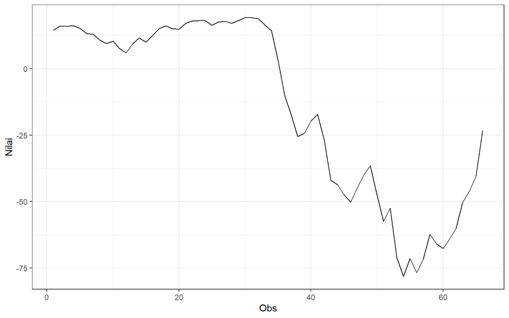

```r
dt_rg2 |> as_tsibble() |>
  ggplot(aes(x = index, y = value)) +
  geom_line() + theme_bw() +
  xlab("Obs") + ylab("Nilai")
```

Berdasarkan plot time series tersebut, terlihat bahwa data tidak stasioner dalam rataan karena masih terdapat tren pada data, dan tidak stasioner dalam ragam karena memiliki lebar pita yang cenderung tidak sama

#### Plot ACF

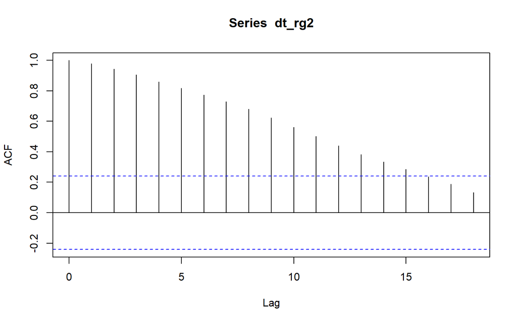

```r
acf(dt_rg2)
```

Berdasarkan plot ACF, terlihat bahwa plot ACF pada data tersebut menurun secara perlahan (*tails off slowly*) yang menandakan data tidak stasioner dalam rataan

#### Uji ADF

```r
adf.test(dt_rg2)
```

```
##
##  Augmented Dickey-Fuller Test
##
## data:  dt_rg2
## Dickey-Fuller = -1.0695, Lag order = 4, p-value = 0.9202
## alternative hypothesis: stationary
```

$H_0$ : Data tidak stasioner dalam rataan

$H_1$ : Data stasioner dalam rataan

Berdasarkan uji ADF tersebut, didapat *p-value* sebesar 0.9202 yang lebih besar dari taraf nyata 5% dan menandakan bahwa data tidak stasioner dalam rataan. Hal ini sesuai dengan hasil eksplorasi menggunakan plot time series dan plot ACF

#### Bagian 3

```r
dt_rg3 <- dt_rg[133:200] |> ts()
mean(dt_rg3)
```

```
## [1] 20.12677
```

```r
var(dt_rg3)
```

```
## [1] 797.5286
```

#### Plot Time Series

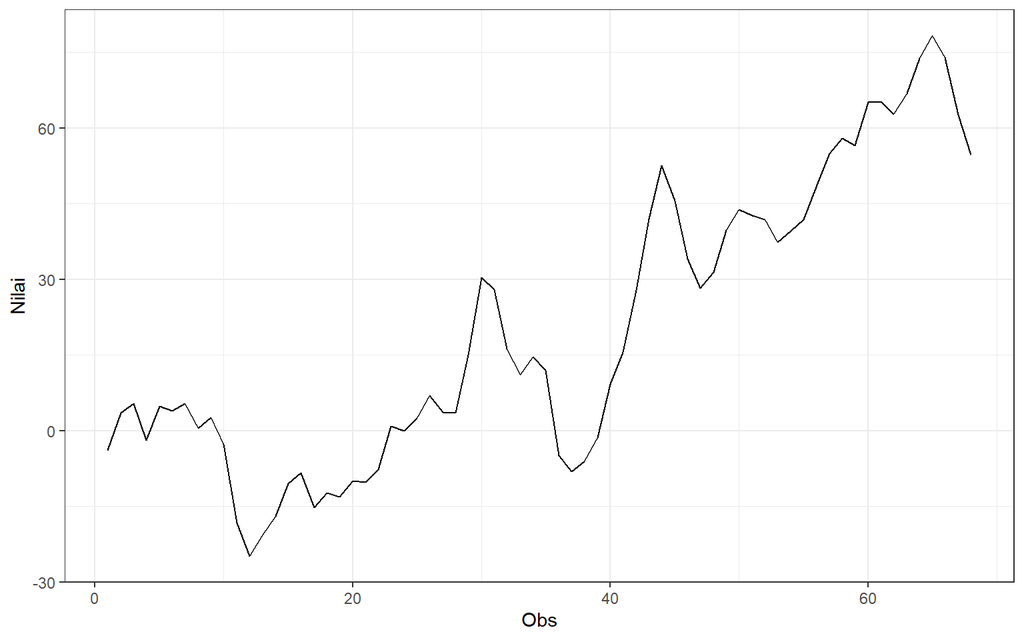

```r
dt_rg3 |> as_tsibble() |>
  ggplot(aes(x = index, y = value)) +
  geom_line() + theme_bw() +
  xlab("Obs") + ylab("Nilai")
```

Berdasarkan plot time series tersebut, terlihat bahwa data tidak stasioner dalam rataan karena masih terdapat tren pada data, namun cenderung stasioner dalam ragam karena memiliki lebar pita yang cenderung sama

#### Plot ACF

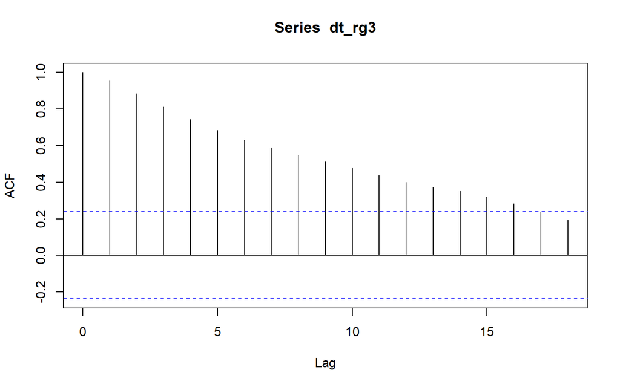

```r
acf(dt_rg3)
```

Berdasarkan plot ACF, terlihat bahwa plot ACF pada data tersebut menurun secara perlahan (*tails off slowly*)yang menandakan data tidak stasioner dalam rataan

#### Uji ADF

```r
tseries::adf.test(dt_rg3,k=5)
```

```
##
##  Augmented Dickey-Fuller Test
##
## data:  dt_rg3
## Dickey-Fuller = -3.1644, Lag order = 5, p-value = 0.1022
## alternative hypothesis: stationary
```

$H_0$ : Data tidak stasioner dalam rataan

$H_1$ : Data stasioner dalam rataan